# Lab 1 - Learning Tidy R With Census Data

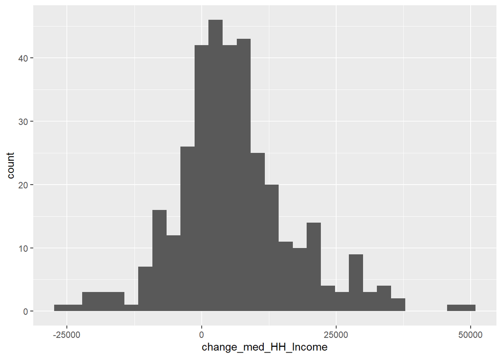

```r
ggplot(allACS) +
  geom_histogram(aes(change_med_HH_Income))
```

Let’s make this a bit more complex, and add some labels.

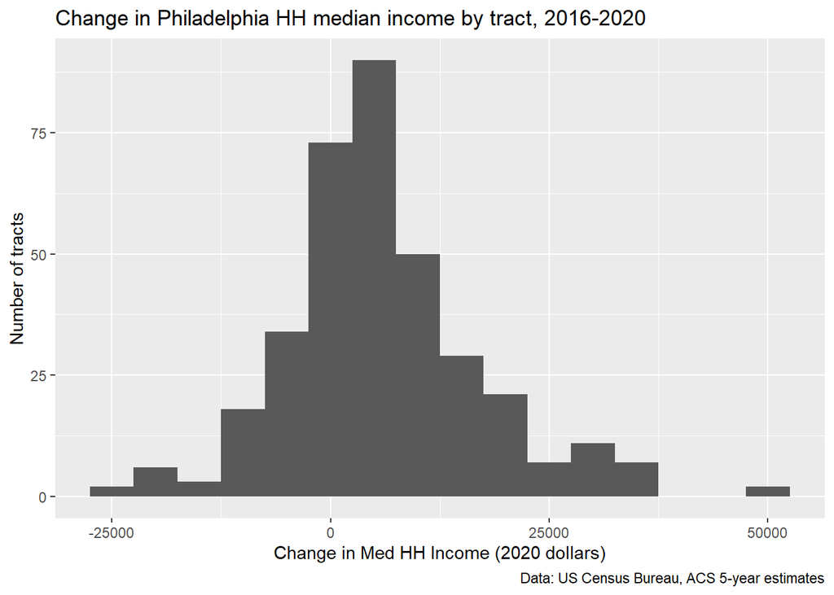

```r
ggplot(allACS)+
  geom_histogram(aes(change_med_HH_Income), binwidth = 5000)+
  labs(
    title = "Change in Philadelphia HH median income by tract, 2016-2020",
    caption = "Data: US Census Bureau, ACS 5-year estimates",
    x="Change in Med HH Income (2020 dollars)",
       y="Number of tracts")
```

Wow, there are some tracts with a huge increase in Med HH Income! What is the simplest explanation for that?

Try adding a theme. Add the end of the last line of code add a plus sign (+) and start typing theme – you will see various built-in themes. Test a few out and see which ones you like. I am a fan of theme_minimal()

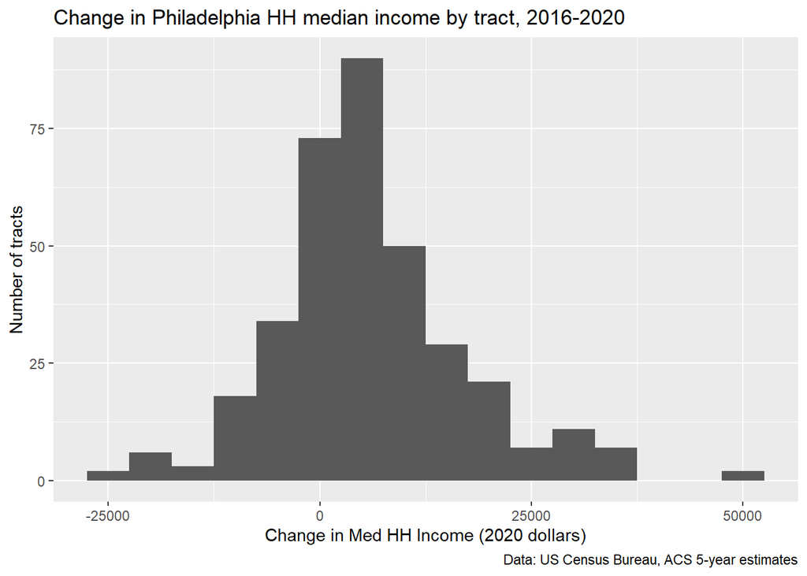

```r
ggplot(allACS)+
  geom_histogram(aes(change_med_HH_Income), binwidth = 5000)+
  labs(
    title = "Change in Philadelphia HH median income by tract, 2016-2020",
    caption = "Data: US Census Bureau, ACS 5-year estimates",
    x="Change in Med HH Income (2020 dollars)",
       y="Number of tracts")
```

Try another geometry type. For example, a boxplot of the same variable.

## Making a summary table

The `summarize` function from the `dplyr` library is very powerful - you can use these summary functions in the context of a table - this is akin to “pivot tables” and other tools from Excel - but this is incredibly simple. You could create a table of statistics and easily export it for use in a report.

```r
summaryTable <- allACS %>%
  summarize(mean_change_HH_Income = mean(change_med_HH_Income, na.rm = TRUE),
            med_change_HH_Income = median(change_med_HH_Income, na.rm = TRUE))
```

# Comparing geographies

Let’s say you are a planner working for the City, and you are creating a neighborhood plan for a particular neighborhood. Our example neighborhood will be Mt. Airy, in Philadelphia’s Northwest section.

Let’s start by making a vector that has the GEOIDs of census tracts in Mt. Airy. The allACS$GEOID column is a CHARACTER, not a number, athough it appears numeric.

We can then create a vactor variable, which we call `mtAiry`, using a “boolean” statement.

We say that if a tract has a GEOID in `myTracts`, the variable `mtAiry` should take on a value of “MT AIRY”, or else it takes on a value of “REST OF PHILADELPHIA”

```r
myTracts <- c("42101023500",
              "42101023600",
              "42101023700",
              "42101025300",
              "42101025400",
              "42101025500",
              "42101025600",
              "42101038800")

allACS <- allACS %>%
  mutate(mtAiry = ifelse(GEOID %in% myTracts, "MT AIRY", "REST OF PHILADELPHIA"))
```

Let’s make a new summary table, this time accounting for the statistics for both Mt. Airy and the rest of the city.

```r
summaryTable2 <- allACS %>%
  group_by(mtAiry) %>%
  summarize(mean_change_HH_Income = mean(change_med_HH_Income, na.rm = TRUE),
            med_change_HH_Income = median(change_med_HH_Income, na.rm = TRUE))
```

## Graphic comparisons Using ggplot2

A graphical approach to subdividing and summarizing the data might make this easier to figure out.

We could compare the distributions between Mt. Airy and the City by taking our histogram we created earlier and using the `facet_wrap` option to subdivide the data and create a side-by-side comparison.

What can we see here about the distributions of the data, and how the distribution and the central tendencies might tell us different stories about what’s happening?

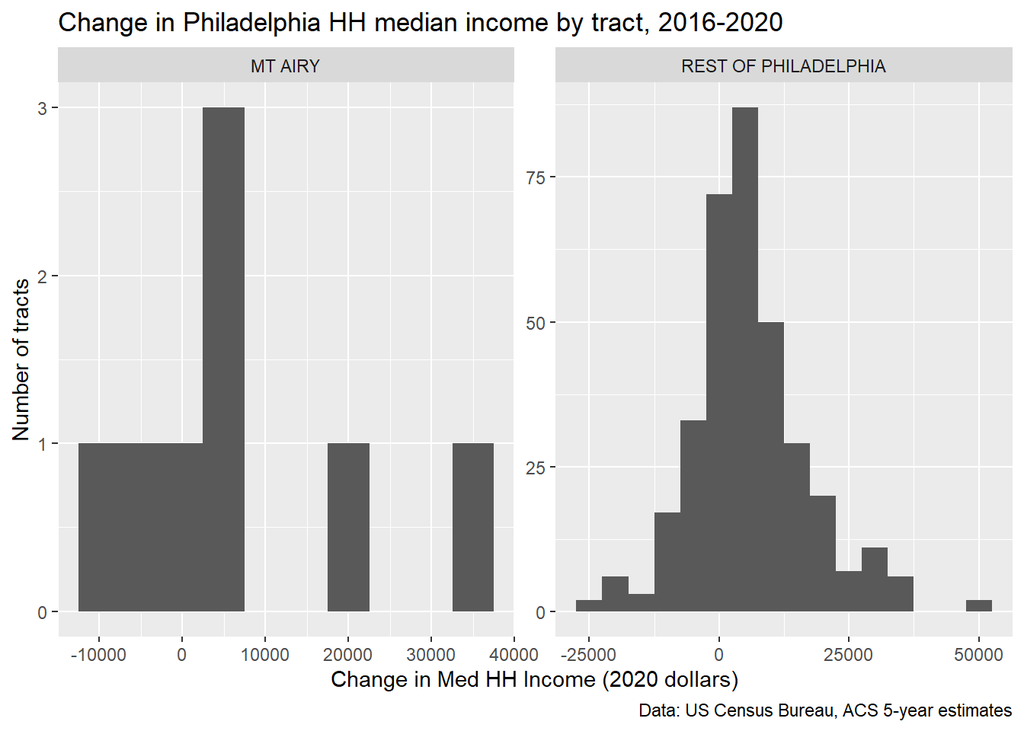

```r
ggplot(allACS)+
  geom_histogram(aes(change_med_HH_Income),
                 binwidth = 5000)+
  labs(
    title = "Change in Philadelphia HH median income by tract, 2016-2020",
    caption = "Data: US Census Bureau, ACS 5-year estimates",
    x="Change in Med HH Income (2020 dollars)",
       y="Number of tracts")+
  facet_wrap(~mtAiry, scales = "free")
```

We can create a scatterplot to see what the relationship is between 2016 and 2020 income and where our Mt. Airy tracts fall.

Notice how we put the inflation adjustment right in the `geom_point` call - you can temporarily create new data inside your ggplot diagrams!

I add a line that represents y=x using `geom_abline`.

What do you think this line represents? How does it help us interpret these points we are seeing?

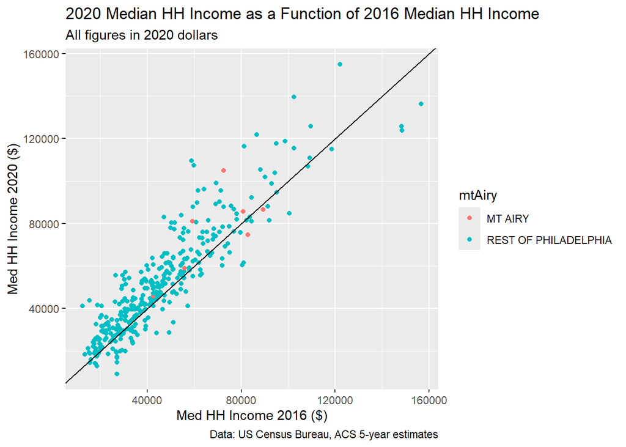

```r
ggplot(allACS)+
  geom_point(aes(x =med_HH_Income.2016 * 1.08,
                 y = med_HH_Income.2020,
                 color = mtAiry))+
  geom_abline(intercept = 0, slope = 1)+
  labs(
    title = "2020 Median HH Income as a Function of 2016 Median HH Income",
    subtitle = "All figures in 2020 dollars",
    caption = "Data: US Census Bureau, ACS 5-year estimates",
    x="Med HH Income 2016 ($)",
    y="Med HH Income 2020 ($)")
```

There are very well established correlations between socio-demographic characteristics and wealth in the US. Philadelphia is no exception. A simple scatterplot is stark evidence of this correlation.

We can plot a `geom_smooth` trendline in here using the `method = "lm"` e.g. a linear fit to see. The default for `geom_smooth` is much more wiggly and may not be the best for visuals like this.

How do our tracts in Mt. Airy look in the context of distribution of wealth and relative to the trend line?

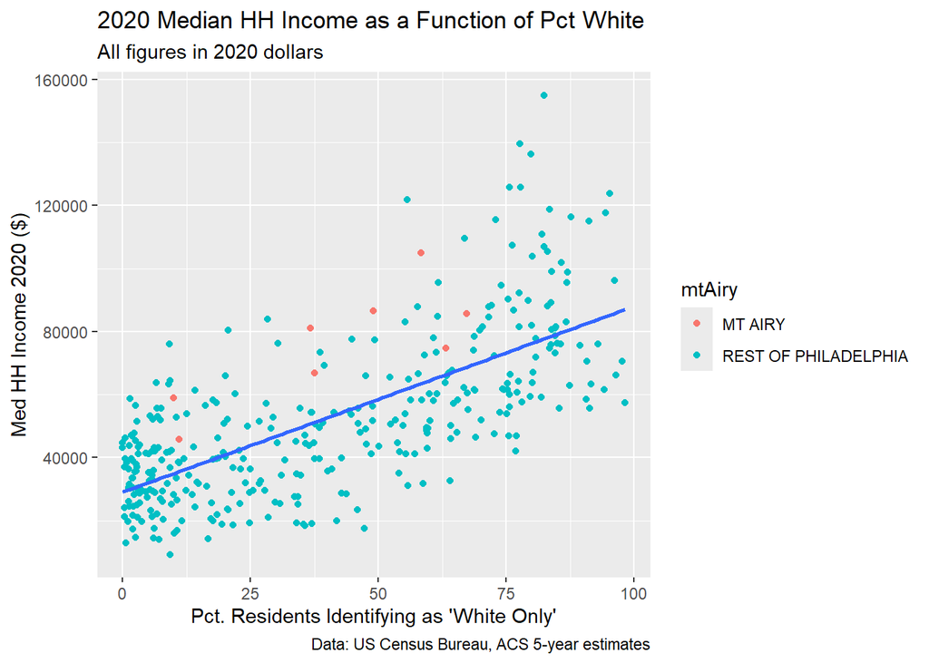

```r
ggplot(allACS)+
  geom_point(aes(x = 100* pctWhite.2020,
                 y = med_HH_Income.2020,
                 color = mtAiry))+
  geom_smooth(aes(x = 100* pctWhite.2020,
                  y = med_HH_Income.2020),
              method = "lm", se = FALSE)+
  labs(
    title = "2020 Median HH Income as a Function of Pct White",
    subtitle = "All figures in 2020 dollars",
    caption = "Data: US Census Bureau, ACS 5-year estimates",
    x="Pct. Residents Identifying as 'White Only'",
    y="Med HH Income 2020 ($)")
```

# Spatial Data and Tidycensus

Tidycensus can also provide us with a geometry for our data. The `sf` package handles shapefiles and interfaces well with `tidycensus` to allow us to analyze and map spatial data. Next lesson we will do some spatial analysis using these data.

Let’s re-run our call for 2020 Census Data and turn the `geometry = TRUE` and then we can make a map of `pctWhite.2020` using the tidycensus data right in ggplot using a special `geom`.

Notice that there is a `geometry` column in our data frame now - it’s actually an `sf` object, which is just like a data frame except it has a column with drawing instructions that you can’t operate on or alter.

Observe the use of the `%>%` operator here - I’m going to chain all of our operations together into one big chunk of code:

```r
acsTractsPHL.2020.sf <- get_acs(geography = "tract",
                             year = 2020,
                             variables = acs_vars,
                             geometry = TRUE,
                             state = "PA",
                             county = "Philadelphia",
                             output = "wide") %>%
  dplyr::select (GEOID, NAME, all_of(acs_vars)) %>%
  rename (total_pop.2020 = B01001_001E,
          total_HU.2020 = B25002_001E,
          total_vacant.2020 = B25002_003E,
          med_HH_Income.2020 = B19013_001E,
          total_White.2020 = B02001_002E,
          total_GradDeg.2020 = B06009_006E) %>%
  mutate(vacancyPct.2020 = total_vacant.2020/total_HU.2020,
         pctWhite.2020 = total_White.2020/total_pop.2020) %>%
  mutate(mtAiry = ifelse(GEOID %in% myTracts, "MT AIRY", "REST OF PHILADELPHIA"))
```

Now we can create a a `geom_sf` which will allow you to map `sf` objects in `ggplot2` so long as they are have their projection set to WGS84 (aka web mercator).

Notice we create a `geom_sf` which symbologizes our data and then another which is designed to represent the boundary of Mt. Airy.

In our next lesson, we will do more detailed cartography and spatial analysis using ggplot - using custom color palettes and more.

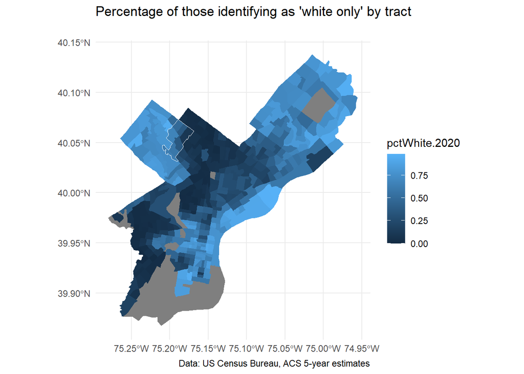

```r
ggplot()+
  geom_sf(data = acsTractsPHL.2020.sf, aes(fill = pctWhite.2020),
          color = "transparent")+
  geom_sf(data = acsTractsPHL.2020.sf %>%
            filter(mtAiry == "MT AIRY") %>%
            st_union(),
          color = "white",
          fill = "transparent")+
  labs(
    title = "Percentage of those identifying as 'white only' by tract",
    subtitle = "",
    caption = "Data: US Census Bureau, ACS 5-year estimates")+
  theme_minimal()
```

# Discussion

- How would you describe the income and demographic statistics and trends in Mt. Airy relative to those of Philadelphia as a whole?
- Do you have a particular hypothesis about “stories” about Mt. Airy based on a look at the data in a spatial format?
- What do you think about the similarities and differences within the neighborhood? How can you probe at those using these data?
- Can you think of any other ways to subdivide the data we looked at in class to glean more insights about Mt. Airy?

# Assignment

- Check the class canvas page to see how this particular markdown needs to be edited to form your first assignment. If there is time in class, begin the assignment!